# FEMSTEM R-Hack

Julia Arenson

4/25/2018

### Introduction

R is a powerful and flexible program that scientists use to analyze and visualize their data. This tutorial is an introduction to the basics of the R language, and to some of the graphing options to you through R.  
First, let’s explore the console (bottom left panel in RStudio). Try typing in the following commands:

```r
1 + 1
2 * 4
8 / 2
```

You can use R like a calculator, by typing in functions and pressing the Enter key. In the console, pressing Enter runs the function. You can save your code by typing it into the code editor (upper left panel). To run code in the editor, press Shift + Enter.  
You can also save variables in the environment (upper right panel). Try saving some variables:

```r
x <- 5
y <- 81
```

The basic syntax for saving objects in R is the name of your new object, an arrow, and the object you want to save.  
R stores these variables, called “x” and “y”, and you can use them in future functions. For example, if you run the above code, then you can do:

```r
x + y
```

which is the same as:

```r
5 + 81
```

R stores different types of data as different classes- numeric, character, or factor. Try creating a character variable, using quotes around the data to denote a character string:

```r
science <- "fun"
```

Beyond single variables, there are a handful of ways R stores data sets. The most common is a data frame, which is like a spreadsheet.

### Functions in R

R has lots of pre-existing functions, which are like shorthand names for the underlying code. The basic format for using functions in R is:

```r
function(arguments)
```

The arguments are specific to the function, and you specify the input data and the settings to control how the function behaves. Just like saving variables, you can save the output of a function to a new object, by using the same basic format:

```r
name <- function(arguments)
```

A useful function is `help()`. The argument for `help()` is the function you need help on. For example, say we want to find the average of our previous variables `x` and `y`, but are not sure how to use the function `mean()`. To bring up the help page for `mean()`:

```r
help(mean)
```

The help page pops up in the bottom right panel. This panel includes toggles for a bunch of things, the most useful of which are the Help and Plots. For now, see the documentation for the function `mean()`. Help pages include the name of the function, a brief description of what the function does, its usage and the arguments to specify, and at the bottom sometimes some helpful examples. Based on the documentation page, let’s try:

```r
mean(x, y)
```

This doesn’t return the average of 5 and 81. The function isn’t reading `x` and `y` together as a single object. We need to tell it that we want the mean of both `x` AND `y`. We can do that by combining our values into a vector, with the function `c()`.

```r
mean(c(x, y))
```

This does return the average of 5 and 81. See how we nested `c()` within `mean()`. R performed `c()` first, then used that output as the argument for `mean()`.

### Getting some data in

R has some publicly available datasets we can import and play around with. Edgar Anderson’s iris dataset has measurements on petal and sepal dimensions for three species of iris. Read in the iris dataset with the following command:

```r
iris <- iris
```

This saves the iris dataset into a new object (a data frame) called `iris`. You can also look at the documentation page for the `iris` dataset with the command `help(iris)`, or just `?iris` (`?` is shorthand for `help()`).

To get a feel for what the `iris` dataset looks like, we can do a few things. First and foremost, you can click on it in the environment, which will bring up the data frame.

We can also look at other attributes with some of these handy functions. `names()` returns the column names of the data frame, so you can see what variables are included. To see the first few rows of data, try `head()`. It can also be useful to see the dimensions (`dim()`) of the data frame, the number of columns (`ncol()`), or the number of rows (`nrow()`).

### Looking at your data

Now that we have a dataset, we can start exploring it with some more functions. Say we want to know which species are included.

```r
unique(iris$Species)
```

`unique()`, just like it sounds, gives you the unique values of the input data. Because we are only interested in the unique values for the Species column, we can specify which column we want to apply the function to within the `iris` dataset with the `$` operand. For the measurements, it may be useful to look at the minimum and maximum values, and measures of central tendency (mean, median, and mode). We used the `mean()` function earlier- try using it now with the `$` operand to get the mean petal length (Petal.Length).

```r
mean(iris$Petal.Length)
```

Additional functions include:

Minimum: `min()`

Maximum: `max()`

Standard deviation: `sd()`

Median: `median()`

There is no built-in function in R for mode. Try googling “mode in R” and see what comes up! There is tons of help for R on the internet, and odds are someone has already figured out a way to do what you want to do. Find a function to find the mode, and try using it on the iris dataset.  
Another way to isolate elements of a data frame is by using indexing `[ ]`. First specify the data frame, followed by the square brackets. Inside the square brackets, you can define rows and columns like so: `[row,column]`. Values before the comma refer to rows, and values after the comma refer to columns. Try isolating the third element in the second column of the `iris` dataset:

```r
iris[3,2]
```

Only specifying the row or the column will print the entire row or column.

We can use indexing inside of other functions as well. Just like we calculated the mean of petal length using the `$` operand and the name of the column, we could use:

```r
mean(iris[,3])
```

because petal length is the 3rd column in the data frame.

To get multiple columns or rows with indexing, you can specify a series of sequential rows or columns with `start:finish`, or use the `c()` function to combine non-sequential indices.

The first four rows of the iris dataset:

```r
iris[1:4,]
```

The first and third column of the iris dataset:

```r
iris[,c(1,3)]
```

Instead of the column or row numbers, you can also use the column/row names. When specifying names, put quotes around it so R knows it is a character string and not an object. Try getting the minimum (`min()`) value of the “Sepal.Width” column:

```r
min(iris[,"Sepal.Width"])
```

We can get the means of several columns at once with the function `colMeans()`. Try calculating the means of sepal length and petal width with indexing.

```r
colMeans(iris[,c("Sepal.Length", "Petal.Width")])
colMeans(iris[,c(1,4)])
```

### Plotting in R

Now that we have a feel for the data, let’s try looking at the data in a meaningful way. When graphing, think about what kind of question you want to answer. We can start with something simple, like “Do petals get wider when they get longer?”  
Base R has some plotting capabilities, but they are somewhat limited and hard to customize. That being said, it’s a good way to get started. The plot function accepts (at a minimum) arguments for the x variable, y variable, and the dataset. The basic formula is:

```r
plot(y ~ x, data)
```

Try plotting petal width (x) against petal length (y):

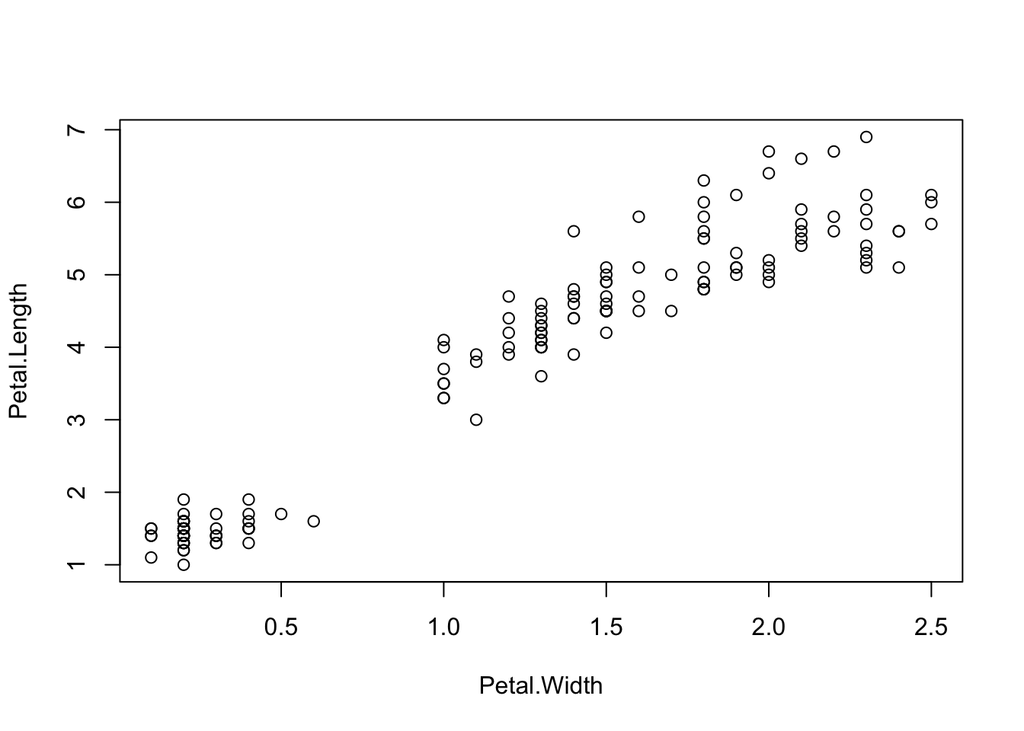

```r
plot(Petal.Length ~ Petal.Width, data = iris)
```

It seems like petal width and length are pretty tightly correlated. In the plot you created, there’s a break in the data. What could explain that? Remember there are three species in the `iris` dataset. Let’s try coloring the points by species, to see if there are differences among species.

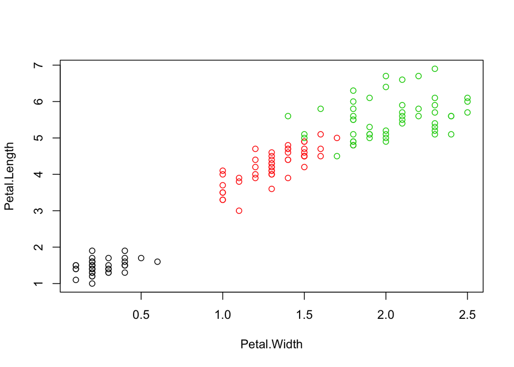

```r
plot(Petal.Length ~ Petal.Width, data = iris, col = Species)
```

Our plot now has separate colors for each species, but no legend telling us which color corresponds to which species. We can add a legend, but it’s a little more complicated.

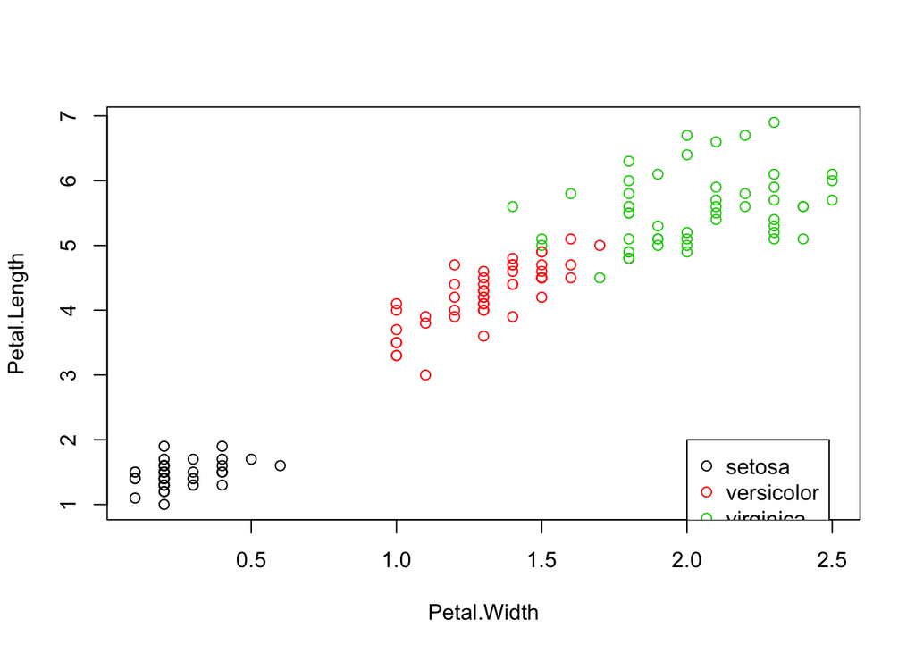

```r
plot(Petal.Length ~ Petal.Width, data = iris, col = Species)
legend(2, 2, unique(iris$Species), col = 1:length(iris$Species), pch = 1)
```

So we first made the plot, and then made the legend on top. We had to specify it’s position, get the names of the different species, correspond that to the colors R selected for each species, and specify the shape the legend should use.

So *setosa* has small petals, and *virginica* has the largest petals. We can also set the labels for the main title and the axis titles relatively simply.

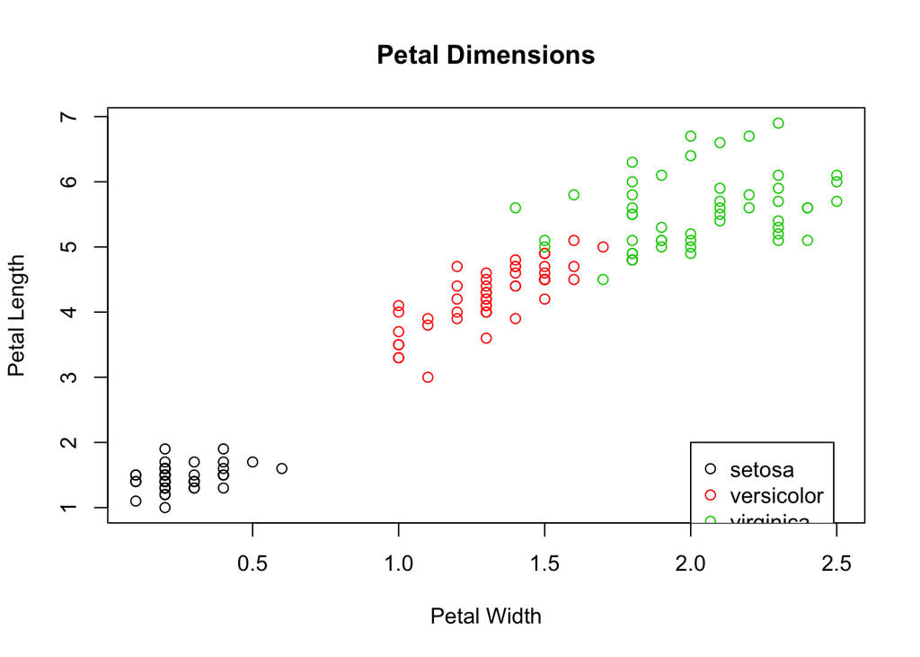

```r
plot(Petal.Length ~ Petal.Width, data = iris, col = Species,
     main = "Petal Dimensions", xlab = "Petal Width", ylab = "Petal Length")
legend(2, 2, unique(iris$Species), col = 1:length(iris$Species), pch = 1)
```

There are some more plot types in base R that can be useful for a quick and dirty plot. For example, you can make a histogram to check the distribution of your data, or a boxplot by species to see who has the longest petals/widest sepals etc.

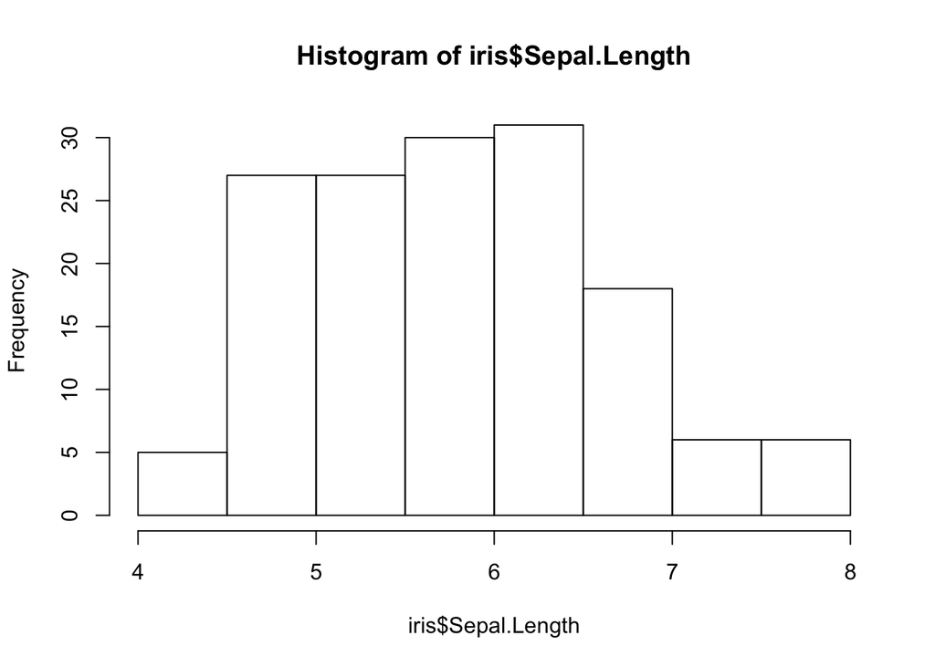

```r
hist(iris$Sepal.Length)
```

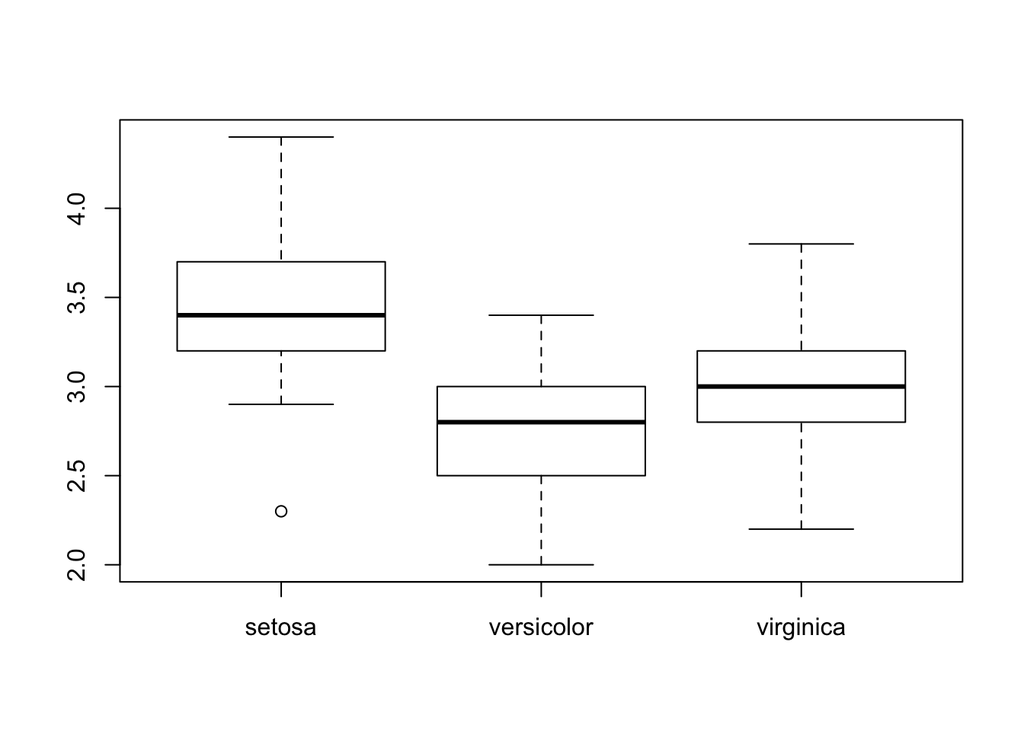

```r
boxplot(Sepal.Width ~ Species, data = iris)
```

However, customization in base R can get gnarly and basic elements of plots aren’t that intuitive to include. This is where `ggplot2` comes in, an R package developed by Hadley Wickham. `ggplot2` is all about making easy to interpret, nice-looking, customizable graphs easily.

### gg-plotting

Packages in R are freely available sets of functions you can import. Base R has a lot to offer, but programmers have expanded a lot on base R with these packages. `ggplot2` offers plotting functions that are much more intuitive and nicer looking (in my opinion) than base R plotting.

First install `ggplot2`:

```r
install.packages("ggplot2")
```

Then load it into your working space:

```r
library(ggplot2)
```

The basic formula for `ggplot2` plotting is as follows:

```r
ggplot(dataset, aes(x, y)) + layers
```

The first call to `ggplot` accepts the names of the data and the variables you want to plot. The variables are defined in the aesthetics mapping. Then, everything else (points, lines, boxplots) are layered on top of the `ggplot` base. Each layer inherits the aesthetics (x and y variables) you specified in the original call to `ggplot`. Data layers are called geometric objects, and other plot elements can be specified by `theme`.  
We plotted petal length and width before in base R. Let’s try it in `ggplot`.

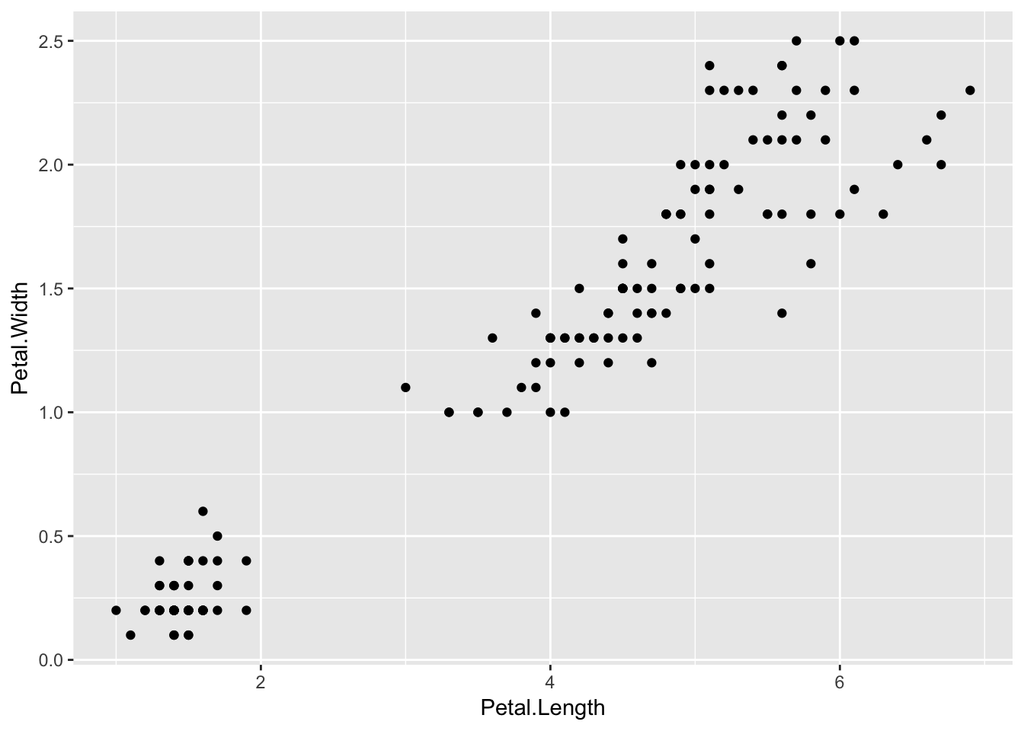

```r
ggplot(iris, aes(Petal.Length, Petal.Width)) +
  geom_point()
```

This looks pretty similar to the base R plot we made earlier, and kind of took more typing. However, if we want to add colors and a legend, that’s where it gets much easier.  
Let’s color the points by species:

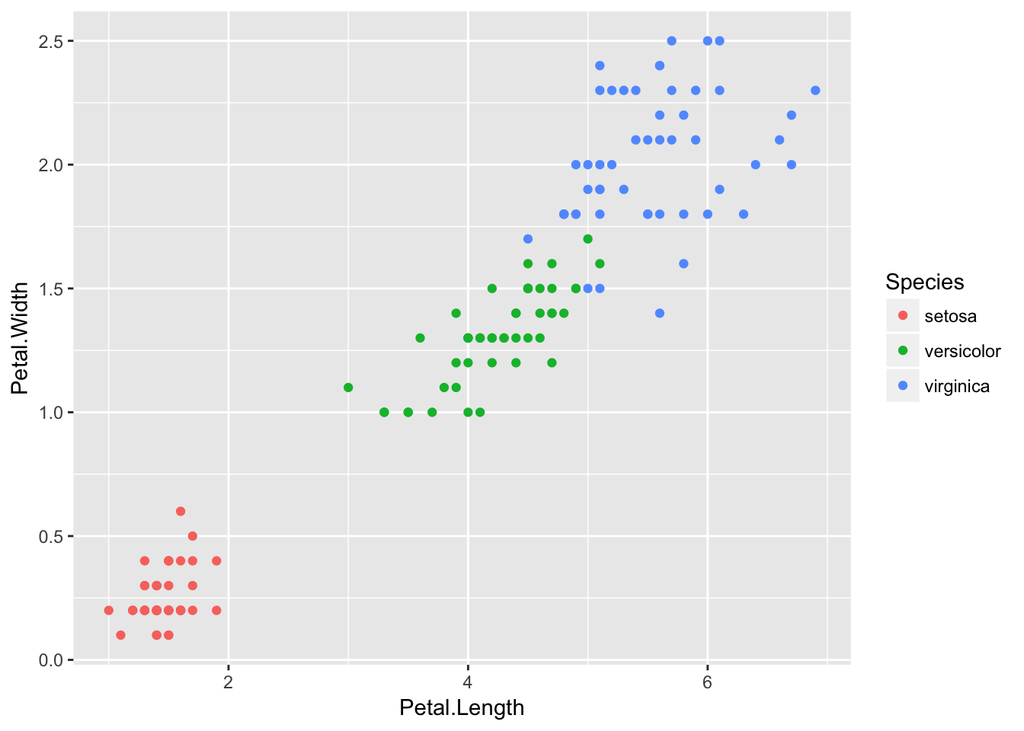

```r
ggplot(iris, aes(Petal.Length, Petal.Width)) +
  geom_point(aes(color = Species))
```

`ggplot` automatically puts up a legend for us, and chooses frankly much nicer colors. We can also change the shape of the points by species:

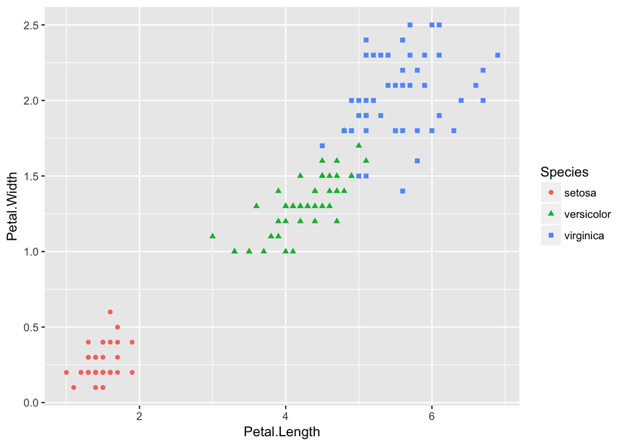

```r
ggplot(iris, aes(Petal.Length, Petal.Width)) +
  geom_point(aes(color = Species, shape = Species))
```

Or to a single shape. R has different shapes, which you can explore with

```r
?pch
```

We can set all the points to chex mix pieces:

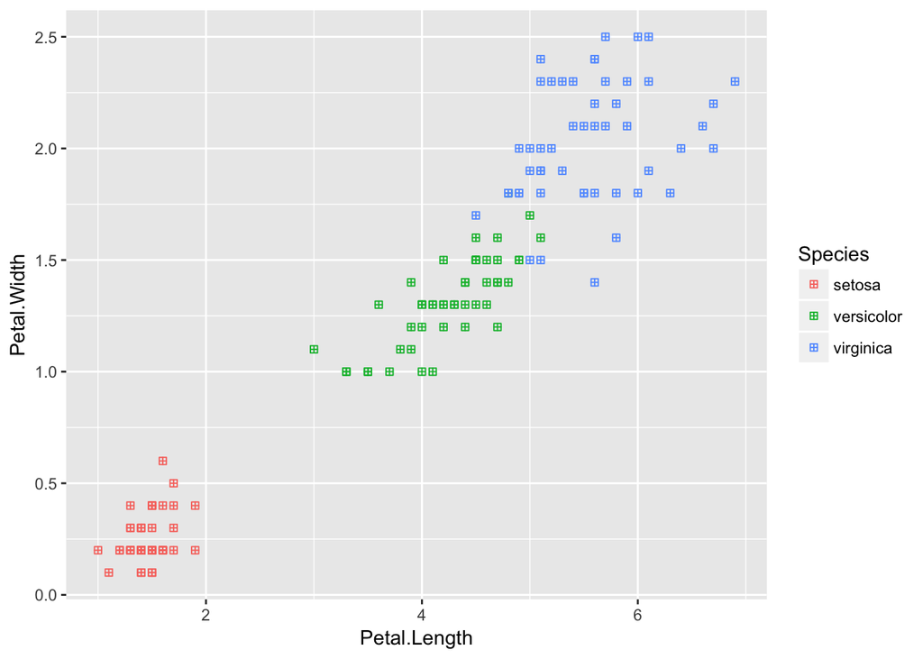

```r
ggplot(iris, aes(Petal.Length, Petal.Width)) +
  geom_point(aes(color = Species), shape = 12)
```

We can also add a line through our plot with another layer:

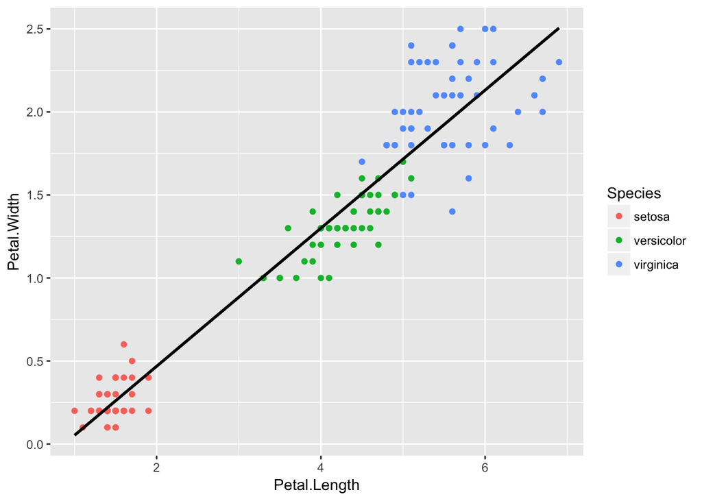

```r
ggplot(iris, aes(Petal.Length, Petal.Width)) +
  geom_point(aes(color = Species)) +
  geom_smooth(method="lm", se=FALSE, color = "black")
```

Or make a boxplot of petal lengths by species:

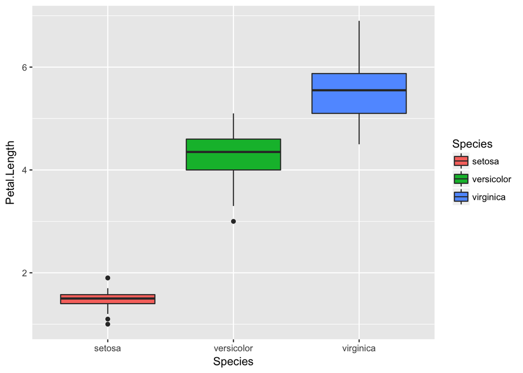

```r
ggplot(iris, aes(Species, Petal.Length)) +
  geom_boxplot(aes(fill = Species))
```

Note that when we want it to color by a variable (here, species), we put the `color =` or `fill =` argument inside `aes()`. When we want the entire layer to be a single color, we leave it outside of `aes()` and put quotes around the color name. `color` is for “outside” colors, like point colors, while `fill` is for “inside” colors, like the inside of box plots.

We can change the plot title and axis titles, and then also the legend title to match:

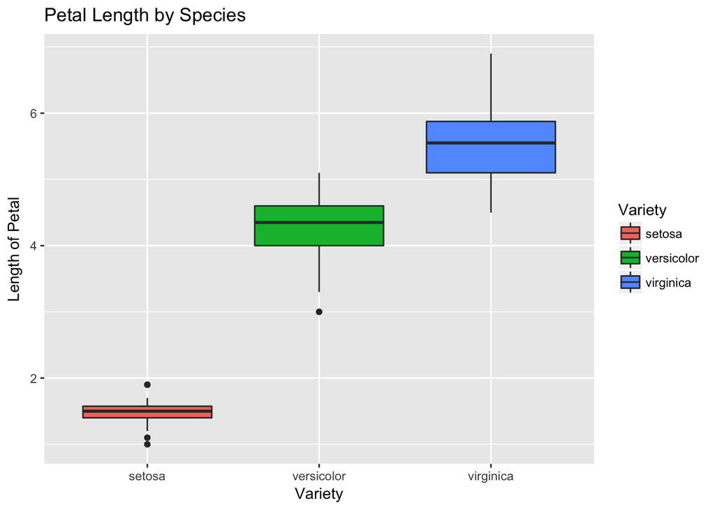

```r
ggplot(iris, aes(Species, Petal.Length)) +
  geom_boxplot(aes(fill = Species)) +
  labs(title = "Petal Length by Species",
       x = "Variety", y = "Length of Petal",
       fill = "Variety")
```

And we can change the `theme`, which controls the display of the plot. The default is `theme_grey()`, but there are several preset alternatives. I like `theme_bw()`, which has gridlines, or `theme_classic()` for a very clean look. Inside of `theme`, you can also set the base font size. The title, axis title, and legend fonts scale accordingly.

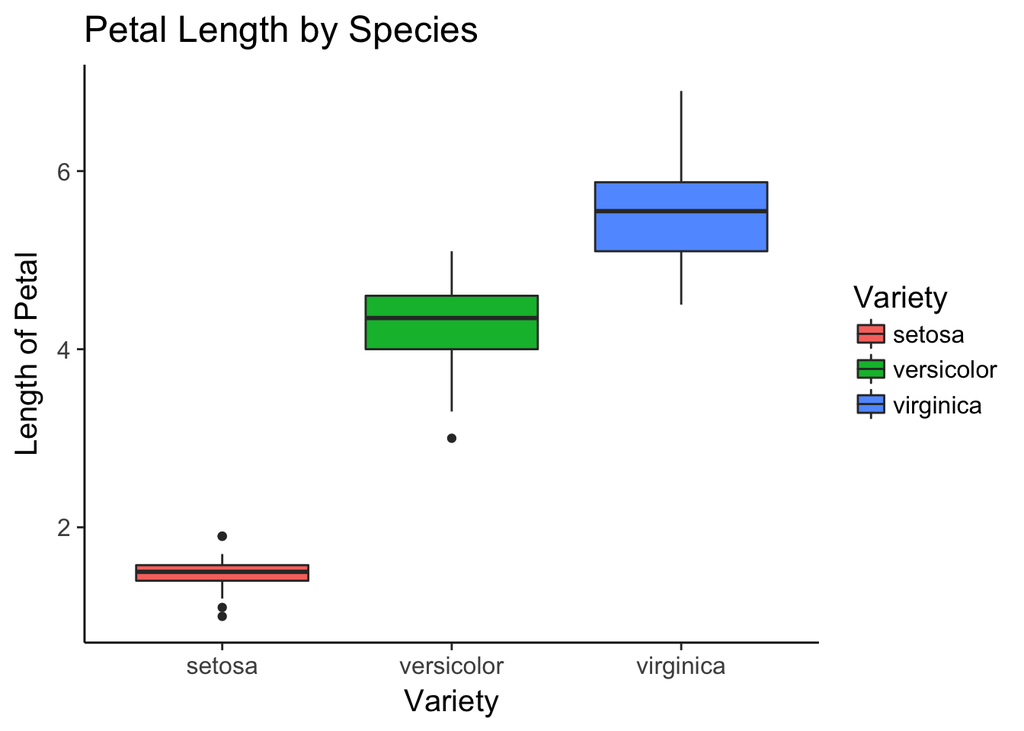

```r
ggplot(iris, aes(Species, Petal.Length)) +
  geom_boxplot(aes(fill = Species)) +
  labs(title = "Petal Length by Species",
       x = "Variety", y = "Length of Petal",
       fill = "Variety") +
  theme_classic(15)
```

We can also make our own color palettes. Some people are red-green colorblind, so this default `ggplot` palette may not be that useful. The RColorBrewer package has several preset color palettes, which you can Google or make R pull up for you with:

```r
RColorBrewer::display.brewer.all()
```

Specify which color palette you want to use with a `scale` layer: here `scale_fill_brewer()` and the name of the palette you want to use.

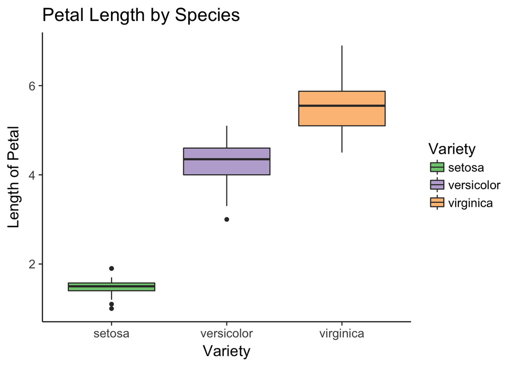

```r
ggplot(iris, aes(Species, Petal.Length)) +
  geom_boxplot(aes(fill = Species)) +
  labs(title = "Petal Length by Species", x = "Variety", y = "Length of Petal",
       fill = "Variety") +
  theme_classic(15) +
  scale_fill_brewer(palette = "Accent")
```

You can also make your own color palettes. Here is a link to a page with the colors you can specify in R: [Colors in R](http://www.stat.columbia.edu/~tzheng/files/Rcolor.pdf). Save a palette as a separate object, so you can refer to it with `scale_color_manual()` or `scale_fill_manual()`.

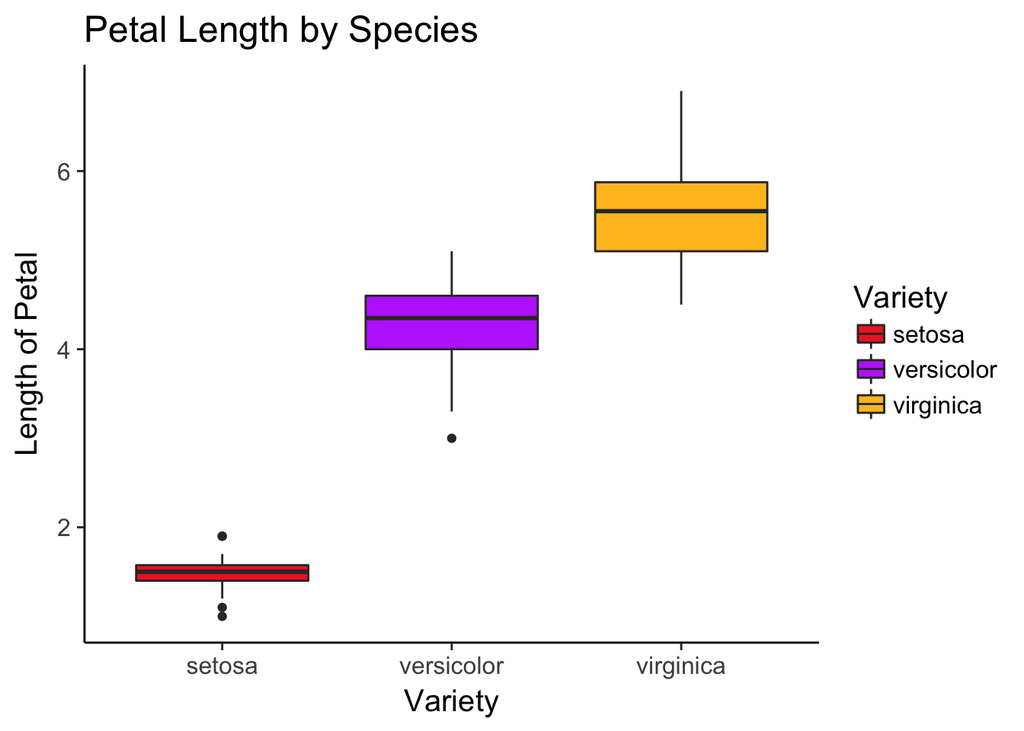

```r
colors <- c("firebrick2", "darkorchid1", "goldenrod1")

ggplot(iris, aes(Species, Petal.Length)) +
  geom_boxplot(aes(fill = Species)) +
  labs(title = "Petal Length by Species", x = "Variety", y = "Length of Petal",
       fill = "Variety") +
  theme_classic(15) +
  scale_fill_manual(values = colors)
```

As you add layers, the code can get long. But hopefully you can see how the individual elements are easier to specify, and the whole deal is more intuitive. Because the graphs are built in layers, each component of the plot is relatively independent.

The `ggplot2` documentation is actually helpful, and many people use it so there are plenty of examples all over the internet to help you figure out how to customize your plot. Try looking at the different geoms to see what kinds of graphs you can make:

```r
help.search("geom_", package = "ggplot2")
```

### More datasets

Explore additional datasets available through R:

```r
data()
```

Some good ones through base R include the `Tree`, `Loblolly`, and `beaver1` datasets (look at their documentation with the command we learned earlier). `ggplot2` also has some datasets you can play around with- `mpg` has data on several car makes, and `diamonds` has prices and other attributes of diamonds.